# Data624_Hw7

Vijaya Cherukuri

10/29/2020

## 6.2. Developing a model to predict permeability (see Sect. 1.4) could save significant resources for a pharmaceutical company, while at the same time more rapidly identifying molecules that have a sufficient permeability to become a drug:

```r
library(dplyr)
library(varImp)
library(elasticnet)
```

### *a.Start R and use these commands to load the data:*

```r
library(AppliedPredictiveModeling)
data(permeability)
str(permeability)
```

```
##  num [1:165, 1] 12.52 1.12 19.41 1.73 1.68 ...
##  - attr(*, "dimnames")=List of 2
##   ..$ : chr [1:165] "1" "2" "3" "4" ...
##   ..$ : chr "permeability"
```

### The matrix fingerprints contains the 1,107 binary molecular predictors for the 165 compounds, while permeability contains permeability response.

### *(b) The fingerprint predictors indicate the presence or absence of substructures of a molecule and are often sparse meaning that relatively few of the molecules contain each substructure. Filter out the predictors that have low frequencies using the nearZeroVar function from the caret package. How many predictors are left for modeling?*

```r
library(caret)
dim(fingerprints)
```

```
## [1]  165 1107
```

#### We have 1107 perdictors as mentioned in ‘a’ part.

```r
fp <- fingerprints[, -nearZeroVar(fingerprints)]
dim(fp)
```

```
## [1] 165 388
```

#### Originally we have 1107 predictors, after using nearzero function we are left out with 388 predictors for modeling.

### *c) Split the data into a training and a test set, pre-process the data, and tune a PLS model. How many latent variables are optimal and what is the corresponding resampled estimate of R2?*

#### Biuld the model

```r
set.seed(17)
trainingRows <- createDataPartition(permeability, p = .80, list= FALSE)

x_train <- fp[trainingRows, ]
y_train <- permeability[trainingRows]

x_test <- fp[-trainingRows, ]
y_test <- permeability[-trainingRows]
```

```r
Pls_Fit <- train(x=x_train,
                y=y_train,
                method='pls',
                metric='Rsquared',
                tuneLength=20,
                trControl=trainControl(method='cv'),
                preProcess=c('center', 'scale')
                )

Pls_Result <- Pls_Fit$results
Pls_Fit
```

```
## Partial Least Squares
##
## 133 samples
## 388 predictors
##
## Pre-processing: centered (388), scaled (388)
## Resampling: Cross-Validated (10 fold)
## Summary of sample sizes: 121, 118, 121, 118, 120, 119, ...
## Resampling results across tuning parameters:
##
##   ncomp  RMSE      Rsquared   MAE
##    1     12.90025  0.3222520   9.941320
##    2     11.68413  0.4581354   8.250378
##    3     11.97359  0.4600123   8.860956
##    4     12.24383  0.4492765   8.896348
##    5     12.01675  0.4693410   8.872978
##    6     12.14125  0.4684395   9.032265
##    7     12.02625  0.4712362   9.194178
##    8     12.13464  0.4669973   9.459727
##    9     12.06592  0.4712771   9.257314
##   10     12.36057  0.4565498   9.496713
##   11     12.81838  0.4400975   9.620152
##   12     13.04478  0.4310474   9.828846
##   13     13.14836  0.4311849   9.831693
##   14     13.58285  0.4095574  10.153620
##   15     14.00005  0.3966119  10.426516
##   16     14.38551  0.3946972  10.706439
##   17     14.64843  0.3835487  10.773578
##   18     14.94472  0.3876079  11.067579
##   19     15.30298  0.3759125  11.357803
##   20     15.58543  0.3663076  11.549326
##
## Rsquared was used to select the optimal model using the largest value.
## The final value used for the model was ncomp = 9.
```

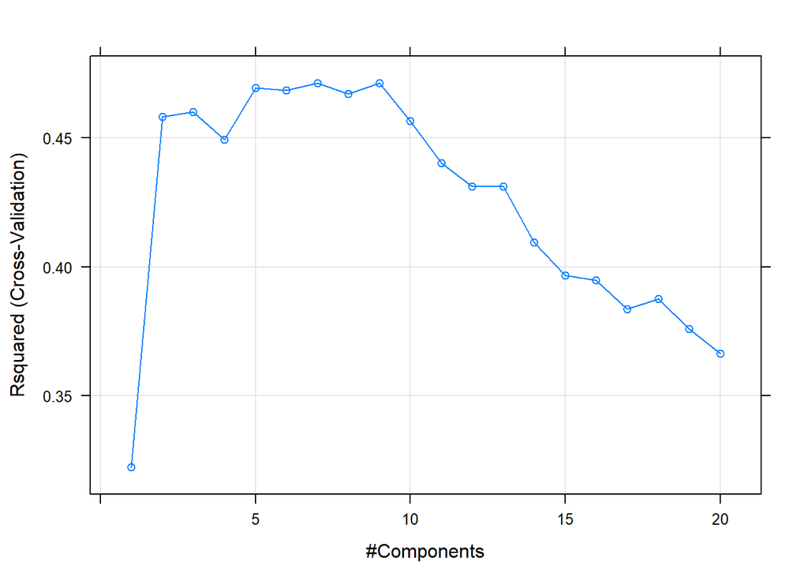

```r
plot(Pls_Fit)
```

### *(d) Predict the response for the test set. What is the test set estimate of R2?*

```r
plsPred <- predict(Pls_Fit, newdata=x_test)
postResample(pred=plsPred, obs=y_test)
```

```
##      RMSE  Rsquared       MAE
## 11.455821  0.530198  8.381798
```

### *(e) Try building other models discussed in this chapter. Do any have better predictive performance?*

#### Build Ridge model

```r
set.seed(17)
ridgeFit <- train(x=x_train,
                  y=y_train,
                  method='ridge',
                  metric='Rsquared',
                  tuneGrid=data.frame(.lambda = seq(0, 1, by=0.1)),
                  trControl=trainControl(method='cv'),
                  preProcess=c('center','scale')
                  )
```

```r
ridgeFit
```

```
## Ridge Regression
##
## 133 samples
## 388 predictors
##
## Pre-processing: centered (388), scaled (388)
## Resampling: Cross-Validated (10 fold)
## Summary of sample sizes: 120, 119, 121, 120, 119, 119, ...
## Resampling results across tuning parameters:
##
##   lambda  RMSE      Rsquared   MAE
##   0.0     17.69824  0.3387828  12.323778
##   0.1     13.16484  0.4586224   9.573189
##   0.2     12.90509  0.4751686   9.501242
##   0.3     13.03168  0.4820743   9.650479
##   0.4     13.30036  0.4863153   9.935894
##   0.5     13.67743  0.4894886  10.256849
##   0.6     14.14675  0.4912908  10.638401
##   0.7     14.66246  0.4929628  11.020308
##   0.8     15.21765  0.4943953  11.426074
##   0.9     15.81805  0.4954898  11.900490
##   1.0     16.44342  0.4964945  12.452772
##
## Rsquared was used to select the optimal model using the largest value.
## The final value used for the model was lambda = 1.
```

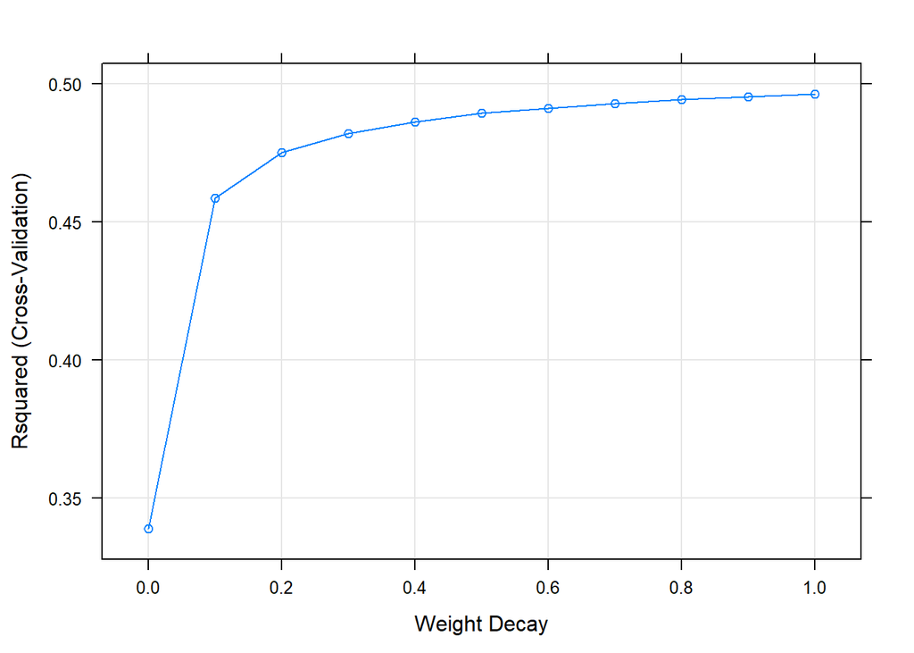

```r
plot(ridgeFit)
```

#### Build lasso model

```r
set.seed(17)
lassoFit <- train(x=x_train,
                  y=y_train,
                  method='lasso',
                  metric='Rsquared',
                  tuneGrid=data.frame(.fraction = seq(0, 0.5, by=0.05)),
                  trControl=trainControl(method='cv'),
                  preProcess=c('center','scale')
                  )

lassoFit
```

```
## The lasso
##
## 133 samples
## 388 predictors
##
## Pre-processing: centered (388), scaled (388)
## Resampling: Cross-Validated (10 fold)
## Summary of sample sizes: 120, 119, 121, 120, 119, 119, ...
## Resampling results across tuning parameters:
##
##   fraction  RMSE      Rsquared   MAE
##   0.00      14.99248        NaN  11.899869
##   0.05      12.04587  0.5004433   8.961563
##   0.10      12.58317  0.4619831   8.828892
##   0.15      14.10187  0.4392581   9.776441
##   0.20      15.02759  0.4202044  10.174406
##   0.25      15.08830  0.4083345  10.103200
##   0.30      15.14589  0.4052072  10.229122
##   0.35      15.18624  0.4047464  10.293555
##   0.40      15.35506  0.3980124  10.405897
##   0.45      15.58076  0.3886588  10.627774
##   0.50      15.84203  0.3764416  10.839115
##
## Rsquared was used to select the optimal model using the largest value.
## The final value used for the model was fraction = 0.05.
```

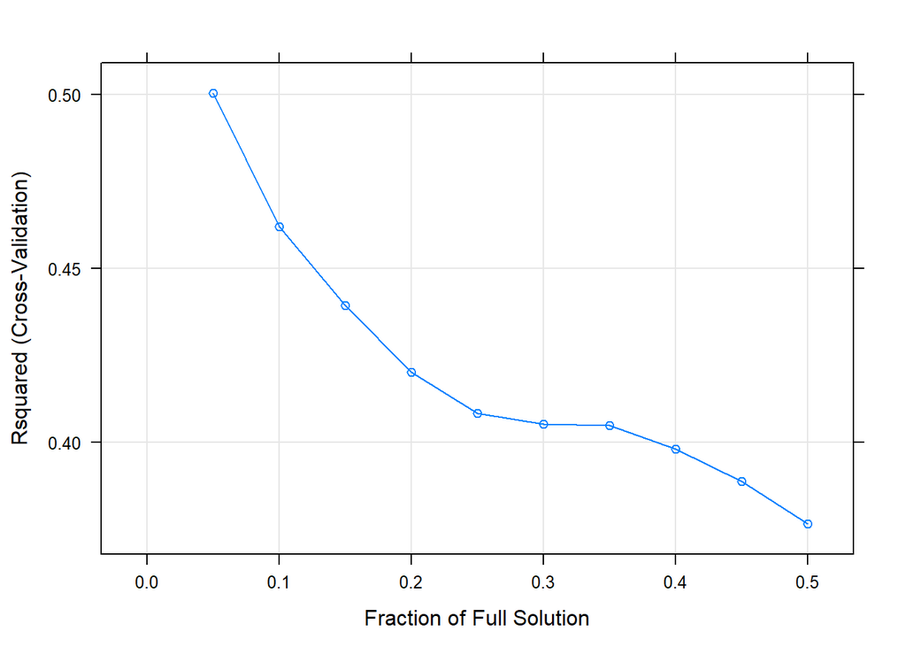

```r
plot(lassoFit)
```

#### Build ElasticNet model

```r
set.seed(1)
enetFit <- train(x=x_train,
                 y=y_train,
                 method='enet',
                 metric='Rsquared',
                 tuneGrid=expand.grid(.fraction = seq(0, 1, by=0.1),
                                      .lambda = seq(0, 1, by=0.1)),
                 trControl=trainControl(method='cv'),
                 preProcess=c('center','scale')
                  )
enetFit
```

```
## Elasticnet
##
## 133 samples
## 388 predictors
##
## Pre-processing: centered (388), scaled (388)
## Resampling: Cross-Validated (10 fold)
## Summary of sample sizes: 120, 120, 120, 119, 120, 119, ...
## Resampling results across tuning parameters:
##
##   lambda  fraction  RMSE      Rsquared   MAE
##   0.0     0.0       15.41970        NaN  12.091419
##   0.0     0.1       11.61723  0.4611141   8.257619
##   0.0     0.2       12.14064  0.4505336   8.783101
##   0.0     0.3       12.78913  0.4447343   9.268132
##   0.0     0.4       13.58610  0.4374408   9.827298
##   0.0     0.5       14.48706  0.4210673  10.382041
##   0.0     0.6       15.26000  0.4102524  10.671864
##   0.0     0.7       15.93989  0.4048366  10.913214
##   0.0     0.8       16.69682  0.3992267  11.321393
##   0.0     0.9       17.48924  0.3871120  11.763618
##   0.0     1.0       18.58494  0.3778306  12.330318
##   0.1     0.0       15.41970        NaN  12.091419
##   0.1     0.1       11.35996  0.4915684   8.017335
##   0.1     0.2       11.27531  0.5015887   8.043442
##   0.1     0.3       11.20513  0.5110566   8.027647
##   0.1     0.4       11.26273  0.5110763   8.129069
##   0.1     0.5       11.49214  0.5022354   8.305879
##   0.1     0.6       11.71000  0.4927793   8.430194
##   0.1     0.7       11.90351  0.4878547   8.538342
##   0.1     0.8       12.11296  0.4819953   8.661963
##   0.1     0.9       12.33892  0.4753494   8.822856
##   0.1     1.0       12.55343  0.4696305   8.992569
##   0.2     0.0       15.41970        NaN  12.091419
##   0.2     0.1       11.29819  0.4971055   8.081225
##   0.2     0.2       11.34551  0.5072120   7.928544
##   0.2     0.3       11.28566  0.5174924   7.990192
##   0.2     0.4       11.30461  0.5220751   8.080592
##   0.2     0.5       11.46627  0.5177649   8.298248
##   0.2     0.6       11.62510  0.5109649   8.433006
```

[output cut: 80 more lines]

```
##   0.9     1.0       15.60098  0.5165384  11.612292
##   1.0     0.0       15.41970        NaN  12.091419
##   1.0     0.1       11.27752  0.5088380   7.975301
##   1.0     0.2       12.93414  0.5159634   8.304355
##   1.0     0.3       13.93146  0.5254618   9.522955
##   1.0     0.4       14.37678  0.5295917  10.179910
##   1.0     0.5       14.76285  0.5301598  10.590262
##   1.0     0.6       15.11221  0.5288528  10.965464
##   1.0     0.7       15.41130  0.5273473  11.279058
##   1.0     0.8       15.70466  0.5250636  11.577120
##   1.0     0.9       15.98121  0.5216979  11.869047
##   1.0     1.0       16.25240  0.5175524  12.137198
##
## Rsquared was used to select the optimal model using the largest value.
## The final values used for the model were fraction = 0.4 and lambda = 0.7.
```

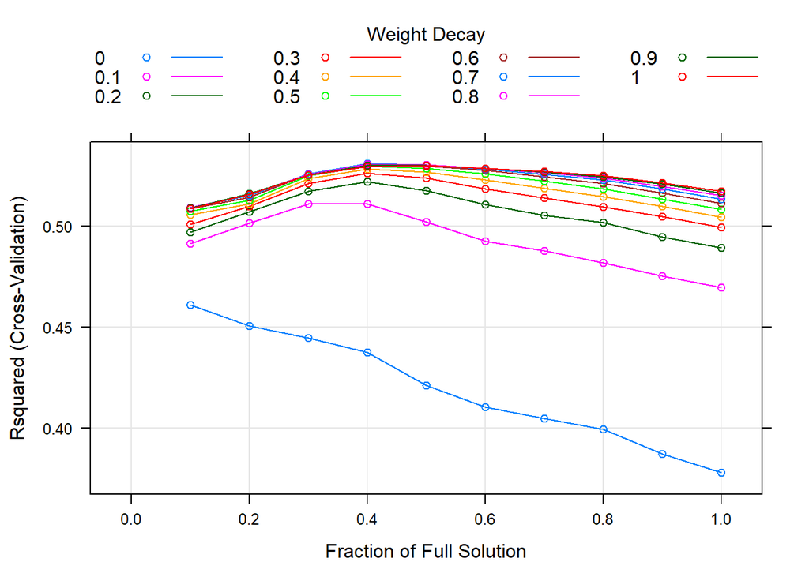

```r
plot(enetFit)
```

#### Compare models

```r
multiResample <- function(models, newdata, obs){
  res = list()
  methods = c()
  i = 1
  for (model in models){
    pred <- predict(model, newdata=newdata)
    metrics <- postResample(pred=pred, obs=obs)
    res[[i]] <- metrics
    methods[[i]] <- model$method
    i <- 1 + i
  }
  names(res) <- methods
  return(res)
}

models <- list(ridgeFit, lassoFit, enetFit)
(resampleResult <- multiResample(models, x_test, y_test))
```

```
## $ridge
##       RMSE   Rsquared        MAE
## 17.4158936  0.5472254 12.8652027
##
## $lasso
##       RMSE   Rsquared        MAE
## 12.9355400  0.3357307  8.6915998
##
## $enet
##       RMSE   Rsquared        MAE
## 14.4535237  0.5122622  9.9411361
```

### *(f) Would you recommend any of your models to replace the permeability laboratory experiment?*

#### Plot a histogram to see what target variable permeability is indicating

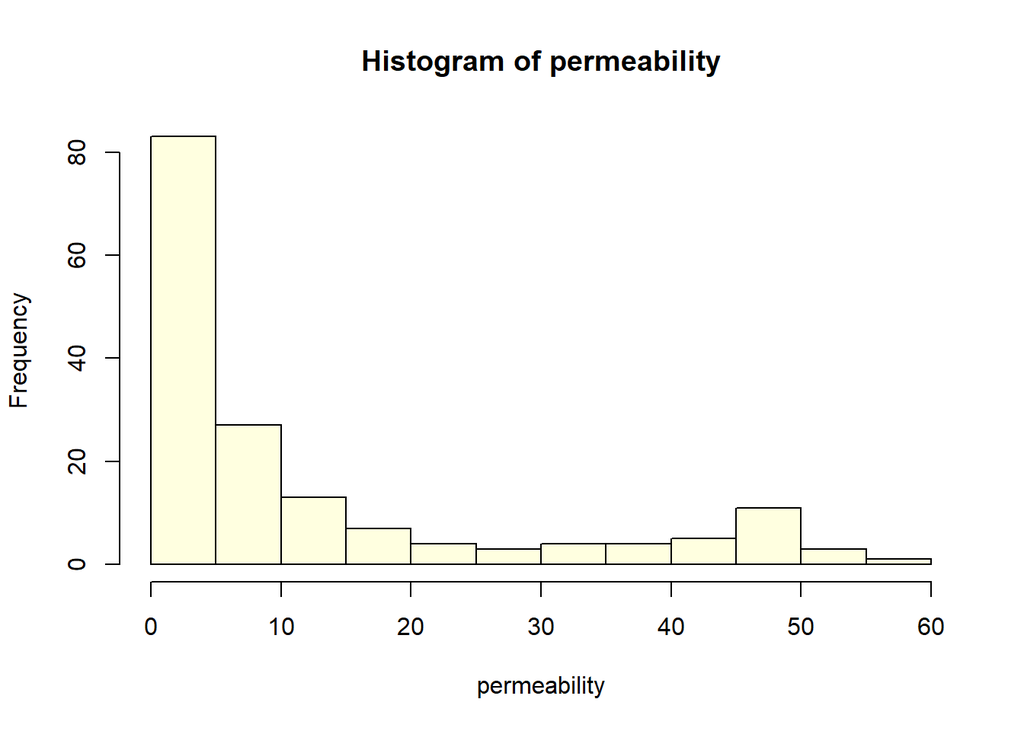

```r
hist(permeability, col="lightyellow")
```

#### The above graph of target variable permeability indicates that most of the results are below 10 and many afe under 5. I would not recommend any other models to replace permeability laboratory experiment.

## 6.3. A chemical manufacturing process for a pharmaceutical product was discussed in Sect. 1.4. In this problem, the objective is to understand the relationship between biological measurements of the raw materials (predictors), measurements of the manufacturing process (predictors), and the response of product yield. Biological predictors cannot be changed but can be used to assess the quality of the raw material before processing. On the other hand, manufacturing process predictors can be changed in the manufacturing process. Improving product yield by 1% will boost revenue by approximately one hundred thousand dollars per batch:

### *(a) Start R and use these commands to load the data:*

```r
library(AppliedPredictiveModeling)
data(ChemicalManufacturingProcess)
str(ChemicalManufacturingProcess)
```

```
## 'data.frame':    176 obs. of  58 variables:
##  $ Yield                 : num  38 42.4 42 41.4 42.5 ...
##  $ BiologicalMaterial01  : num  6.25 8.01 8.01 8.01 7.47 6.12 7.48 6.94 6.94 6.94 ...
##  $ BiologicalMaterial02  : num  49.6 61 61 61 63.3 ...
##  $ BiologicalMaterial03  : num  57 67.5 67.5 67.5 72.2 ...
##  $ BiologicalMaterial04  : num  12.7 14.6 14.6 14.6 14 ...
##  $ BiologicalMaterial05  : num  19.5 19.4 19.4 19.4 17.9 ...
##  $ BiologicalMaterial06  : num  43.7 53.1 53.1 53.1 54.7 ...
##  $ BiologicalMaterial07  : num  100 100 100 100 100 100 100 100 100 100 ...
##  $ BiologicalMaterial08  : num  16.7 19 19 19 18.2 ...
##  $ BiologicalMaterial09  : num  11.4 12.6 12.6 12.6 12.8 ...
##  $ BiologicalMaterial10  : num  3.46 3.46 3.46 3.46 3.05 3.78 3.04 3.85 3.85 3.85 ...
##  $ BiologicalMaterial11  : num  138 154 154 154 148 ...
##  $ BiologicalMaterial12  : num  18.8 21.1 21.1 21.1 21.1 ...
##  $ ManufacturingProcess01: num  NA 0 0 0 10.7 12 11.5 12 12 12 ...
```

[output cut: 44 more lines]

### The matrix processPredictors contains the 57 predictors (12 describing the input biological material and 45 describing the process predictors) for the 176 manufacturing runs. yield contains the percent yield for each run.

### *(b) A small percentage of cells in the predictor set contain missing values. Use an imputation function to fill in these missing values (e.g., see Sect. 3.8).*

#### We will use the missmap function available in Amelia package to find out the missing values

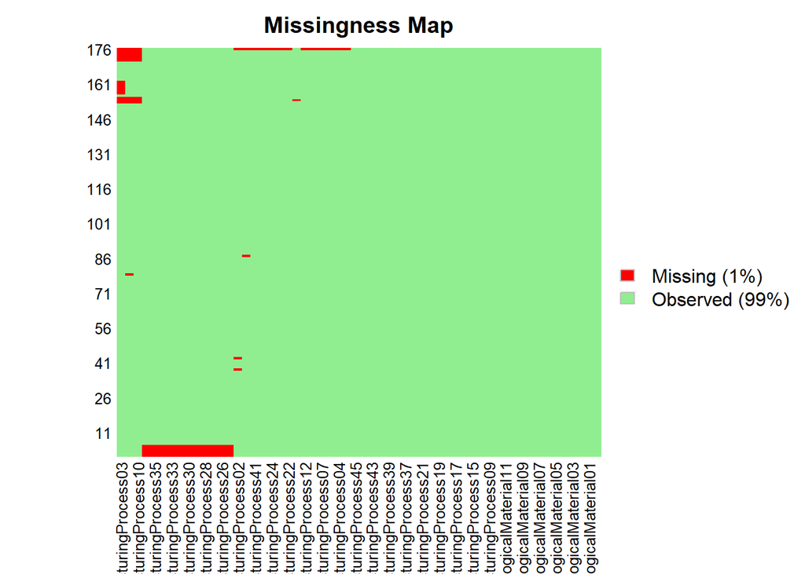

```r
library(Amelia)
missmap(ChemicalManufacturingProcess, col = c("red", "lightgreen"))
```

#### Use bagImpute method to impute missing values

```r
cmpImpute <- preProcess(ChemicalManufacturingProcess[,-c(1)], method=c('bagImpute'))
cmpImpute
```

```
## Created from 152 samples and 57 variables
##
## Pre-processing:
##   - bagged tree imputation (57)
##   - ignored (0)
```

### *(c) Split the data into a training and a test set, pre-process the data, and tune a model of your choice from this chapter. What is the optimal value of the performance metric?*

```r
cmp <- predict(cmpImpute, ChemicalManufacturingProcess[,-c(1)])

set.seed(43)
trainRow <- createDataPartition(ChemicalManufacturingProcess$Yield, p=0.8, list=FALSE)
x_train <- cmp[trainRow, ]
y_train <- ChemicalManufacturingProcess$Yield[trainRow]
x_test <- cmp[-trainRow, ]
y_test <- ChemicalManufacturingProcess$Yield[-trainRow]
```

#### I would like to go with Elastic Net model. Lambda ranges b/w 0 and 1. RMSE is used as metric

```r
set.seed(43)
enetFit <- train(x=x_train,
                 y=y_train,
                 method='enet',
                 metric='RMSE',
                 tuneGrid=expand.grid(.fraction = seq(0, 1, by=0.1),
                                      .lambda = seq(0, 1, by=0.1)),
                 trControl=trainControl(method='cv'),
                 preProcess=c('center','scale')
                  )
enetFit
```

```
## Elasticnet
##
## 144 samples
##  57 predictor
##
## Pre-processing: centered (57), scaled (57)
## Resampling: Cross-Validated (10 fold)
## Summary of sample sizes: 129, 128, 129, 130, 128, 132, ...
## Resampling results across tuning parameters:
##
##   lambda  fraction  RMSE      Rsquared   MAE
##   0.0     0.0       1.837579        NaN  1.5027873
##   0.0     0.1       1.153943  0.6317800  0.9496645
##   0.0     0.2       1.191060  0.6415414  0.9760286
##   0.0     0.3       1.558044  0.5769679  1.1124035
##   0.0     0.4       1.562566  0.5612475  1.1299345
##   0.0     0.5       1.829464  0.5492713  1.2209208
##   0.0     0.6       1.974977  0.4871427  1.2844440
##   0.0     0.7       2.186136  0.4600333  1.3630239
##   0.0     0.8       2.578256  0.4428648  1.4911103
##   0.0     0.9       3.092682  0.4281391  1.6573366
##   0.0     1.0       3.586090  0.4161821  1.8128366
##   0.1     0.0       1.837579        NaN  1.5027873
##   0.1     0.1       1.475418  0.5827890  1.2125458
##   0.1     0.2       1.228611  0.6227175  1.0102915
##   0.1     0.3       1.151070  0.6460293  0.9345442
##   0.1     0.4       1.172960  0.6396914  0.9529404
##   0.1     0.5       1.162016  0.6473431  0.9507579
##   0.1     0.6       1.197514  0.6424282  0.9778761
##   0.1     0.7       1.261270  0.6274234  1.0017188
##   0.1     0.8       1.395986  0.6021707  1.0516632
##   0.1     0.9       1.516766  0.5861941  1.0933444
##   0.1     1.0       1.647637  0.5741893  1.1348207
##   0.2     0.0       1.837579        NaN  1.5027873
##   0.2     0.1       1.508063  0.5667096  1.2368413
##   0.2     0.2       1.258721  0.6215993  1.0383243
##   0.2     0.3       1.165234  0.6344964  0.9515930
##   0.2     0.4       1.159147  0.6437809  0.9467027
##   0.2     0.5       1.182903  0.6403331  0.9595233
##   0.2     0.6       1.237500  0.6300853  0.9918226
```

[output cut: 80 more lines]

```
##   0.9     1.0       1.545960  0.6317086  1.2040185
##   1.0     0.0       1.837579        NaN  1.5027873
##   1.0     0.1       1.499407  0.5468504  1.2287872
##   1.0     0.2       1.253831  0.6122372  1.0288687
##   1.0     0.3       1.177862  0.6141065  0.9532678
##   1.0     0.4       1.224033  0.6190712  0.9760137
##   1.0     0.5       1.289279  0.6265507  1.0299626
##   1.0     0.6       1.364109  0.6247438  1.0947809
##   1.0     0.7       1.430693  0.6266091  1.1432180
##   1.0     0.8       1.492621  0.6260592  1.1876569
##   1.0     0.9       1.550088  0.6261552  1.2232392
##   1.0     1.0       1.605355  0.6267026  1.2614448
##
## RMSE was used to select the optimal model using the smallest value.
## The final values used for the model were fraction = 0.4 and lambda = 0.3.
```

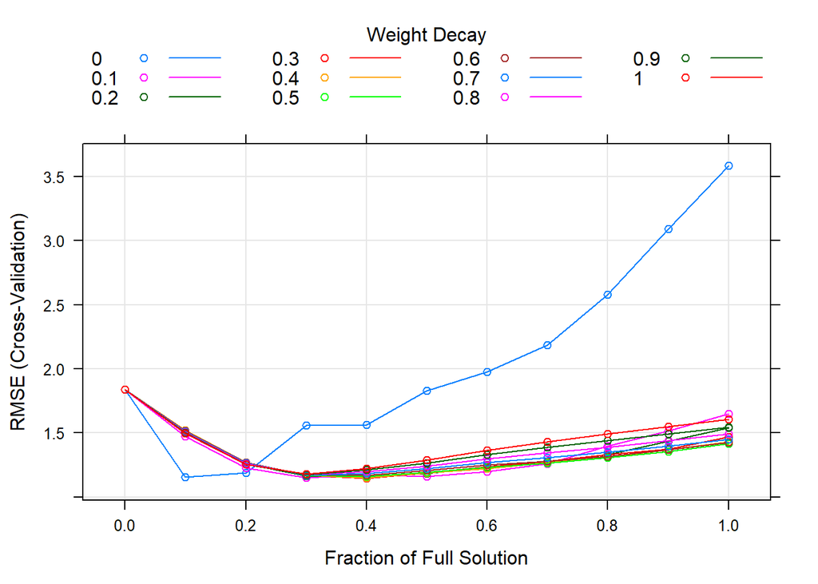

```r
plot(enetFit)
```

### *(d) Predict the response for the test set. What is the value of the performance metric and how does this compare with the resampled performance metric on the training set?*

```r
enet_Pred <- predict(enetFit, newdata=x_test)
(predResult <- postResample(pred=enet_Pred, obs=y_test))
```

```
##      RMSE  Rsquared       MAE
## 1.2777021 0.5180167 1.0508293
```

### *(e) Which predictors are most important in the model you have trained? Do either the biological or process predictors dominate the list?*

```r
coeffs <- predict.enet(enetFit$finalModel, s=enetFit$bestTune[1, "fraction"], type="coef", mode="fraction")$coefficients
```

#### Display the predictors

```r
coeffs
```

```
##   BiologicalMaterial01   BiologicalMaterial02   BiologicalMaterial03
##            0.000000000            0.090381195            0.107121492
##   BiologicalMaterial04   BiologicalMaterial05   BiologicalMaterial06
##            0.000000000            0.000000000            0.185876248
##   BiologicalMaterial07   BiologicalMaterial08   BiologicalMaterial09
##           -0.009778043            0.000000000            0.000000000
##   BiologicalMaterial10   BiologicalMaterial11   BiologicalMaterial12
##            0.000000000            0.000000000            0.000000000
## ManufacturingProcess01 ManufacturingProcess02 ManufacturingProcess03
##            0.000000000            0.000000000            0.000000000
## ManufacturingProcess04 ManufacturingProcess05 ManufacturingProcess06
##            0.000000000            0.000000000            0.066438839
## ManufacturingProcess07 ManufacturingProcess08 ManufacturingProcess09
##            0.000000000            0.000000000            0.321989134
## ManufacturingProcess10 ManufacturingProcess11 ManufacturingProcess12
##            0.000000000            0.162601998            0.000000000
## ManufacturingProcess13 ManufacturingProcess14 ManufacturingProcess15
##           -0.250483963            0.000000000            0.002777623
## ManufacturingProcess16 ManufacturingProcess17 ManufacturingProcess18
##            0.000000000           -0.237350284            0.000000000
## ManufacturingProcess19 ManufacturingProcess20 ManufacturingProcess21
##            0.000000000            0.000000000            0.000000000
## ManufacturingProcess22 ManufacturingProcess23 ManufacturingProcess24
##            0.000000000            0.000000000            0.000000000
## ManufacturingProcess25 ManufacturingProcess26 ManufacturingProcess27
##            0.000000000            0.000000000            0.000000000
## ManufacturingProcess28 ManufacturingProcess29 ManufacturingProcess30
##            0.000000000            0.000000000            0.015616362
## ManufacturingProcess31 ManufacturingProcess32 ManufacturingProcess33
##            0.000000000            0.597941780            0.027730790
## ManufacturingProcess34 ManufacturingProcess35 ManufacturingProcess36
##            0.073053036            0.000000000           -0.341087523
## ManufacturingProcess37 ManufacturingProcess38 ManufacturingProcess39
##           -0.084284710            0.000000000            0.105507516
## ManufacturingProcess40 ManufacturingProcess41 ManufacturingProcess42
##            0.000000000            0.000000000            0.015801489
## ManufacturingProcess43 ManufacturingProcess44 ManufacturingProcess45
##            0.000000000            0.052531419            0.000000000
```

#### Bassed on above results we can observe some of the predictors are zero.

#### Lets find out the important predictors

```r
coeffs.sorted <- abs(coeffs)
coeffs.sorted <- coeffs.sorted[coeffs.sorted>0]
(coeffs.sorted <- sort(coeffs.sorted, decreasing = T))
```

```
## ManufacturingProcess32 ManufacturingProcess36 ManufacturingProcess09
##            0.597941780            0.341087523            0.321989134
## ManufacturingProcess13 ManufacturingProcess17   BiologicalMaterial06
##            0.250483963            0.237350284            0.185876248
## ManufacturingProcess11   BiologicalMaterial03 ManufacturingProcess39
##            0.162601998            0.107121492            0.105507516
##   BiologicalMaterial02 ManufacturingProcess37 ManufacturingProcess34
##            0.090381195            0.084284710            0.073053036
## ManufacturingProcess06 ManufacturingProcess44 ManufacturingProcess33
##            0.066438839            0.052531419            0.027730790
## ManufacturingProcess42 ManufacturingProcess30   BiologicalMaterial07
##            0.015801489            0.015616362            0.009778043
## ManufacturingProcess15
##            0.002777623
```

```r
(temp <- varImp(enetFit))
```

```
## loess r-squared variable importance
##
##   only 20 most important variables shown (out of 57)
##
##                        Overall
## ManufacturingProcess32  100.00
## BiologicalMaterial06     86.37
## ManufacturingProcess13   81.45
## ManufacturingProcess36   79.55
## BiologicalMaterial02     72.25
## BiologicalMaterial03     71.20
## BiologicalMaterial12     69.06
## ManufacturingProcess17   66.66
## ManufacturingProcess31   65.89
## ManufacturingProcess09   64.72
## ManufacturingProcess06   53.51
## ManufacturingProcess33   52.91
## BiologicalMaterial11     51.56
## BiologicalMaterial04     49.23
## ManufacturingProcess11   47.70
## BiologicalMaterial08     45.57
## ManufacturingProcess30   43.23
## BiologicalMaterial01     39.25
## ManufacturingProcess29   38.88
## ManufacturingProcess02   32.81
```

### *(f) Explore the relationships between each of the top predictors and the response. How could this information be helpful in improving yield in future runs of the manufacturing process?*

#### This part can be easily analyzed by checking the number of positive and negative coefficients. If we have more positive coefficients then it yield will be imporoved and for negative coeffecients it is viceversa.

#### Positive coefficeints for Maufacturing Process

```r
coeffs_mp <- coeffs.sorted[grep('ManufacturingProcess', names(coeffs.sorted))] %>% names() %>% coeffs[.]
coeffs_mp[coeffs_mp>0]
```

```
## ManufacturingProcess32 ManufacturingProcess09 ManufacturingProcess11
##            0.597941780            0.321989134            0.162601998
## ManufacturingProcess39 ManufacturingProcess34 ManufacturingProcess06
##            0.105507516            0.073053036            0.066438839
## ManufacturingProcess44 ManufacturingProcess33 ManufacturingProcess42
##            0.052531419            0.027730790            0.015801489
## ManufacturingProcess30 ManufacturingProcess15
##            0.015616362            0.002777623
```

#### Negative coefficeints for Maufacturing Process

```r
coeffs_mp[coeffs_mp<0]
```

```
## ManufacturingProcess36 ManufacturingProcess13 ManufacturingProcess17
##            -0.34108752            -0.25048396            -0.23735028
## ManufacturingProcess37
##            -0.08428471
```